# Risky Behaviors

How do risky behaviors predict student academic achievement?

by Andrea Chamorro, Mariam Khan, Janani Shankaran; Georgetown University’s McCourt School of Public Policy

May 8, 2017

# Introduction

For several decades, the academic performance of students has been a major concern. Many studies have discovered that academic success has been strongly linked with health-related factors. According to the Centers for Disease Control and the 2009 National Youth Risk Behavior Survey (YRBS), there is a negative association between health-risk behaviors and academic achievement among high school students. In other words, students with higher grades are less likely to engage in health-risk behaviors than students with lower grades. Similarly, students who do not engage in health-risk behaviors are more likely to receive higher grades than students who engage in health-risk behaviors. It should be noted these associations do not prove causation.

The objective of this study is to build upon the CDC research in order to better understand how certain behaviors may impact or be associated with student grades. These results can encourage schools to promote health and safety among students, which would in turn enable students to establish lifelong healthy behaviors.

# Data

The City of Somerville’s Youth Risk Behavior Survey is an annual student survey conducted at Somerville High School. Students at the school were surveyed every two years, from 2002 to 2014. The dataset includes a total of 8,003 student survey responses. The dataset can be accessed here: http://bit.ly/2nRvJYa.

```r
##Download data
temp <- tempfile()
download.file("https://raw.githubusercontent.com/GeorgetownMcCourt/riskybehavior/master/Data/Somerville_High_School_YRBS_Raw_Data_2002-2014.csv", temp, mode="wb")
df <- read.csv(temp)

###Libraries###
library(plyr)
library(Hmisc)
library(MASS)
library(pscl)
library(randomForest)
library(VIM)
library(rpart)
library(rpart.plot)
library(ggplot2)
library(gridExtra)
library(plotROC)

meanf1 <- function(actual, predicted){
  #Mean F1 score function
  #actual = a vector of actual labels
  #predicted = predicted labels
  classes <- unique(actual)
  results <- data.frame()
  for(k in classes){
    results <- rbind(results,
                     data.frame(class.name = k,
                                weight = sum(actual == k)/length(actual),
                                precision = sum(predicted == k & actual == k)/sum(predicted == k),
                                recall = sum(predicted == k & actual == k)/sum(actual == k)))
  }
  results$score <- results$weight * 2 * (results$precision * results$recall) / (results$precision + results$recall)
  return(sum(results$score))
}
```

# Descriptive statistics

In terms of demographic characteristics, roughly 40.1 percent of students are White, 15.0 percent are Black, 24.4 percent are Hispanic, 8.7 percent are Asian, and 11.8 percent identify as Other race. In addition, 219 observations exhibit missingness in race. Approximately 52.4 percent of the sample is female, while the average age of students is 16.25.

Among the risky behaviors, students are most likely to have engaged in sexual activity or consumed alcohol. Some of the variables exhibit considerable missingness, including variables related to hurting oneself, gang affiliation, altercations, and drug use. The variables are summarized below. Among students who responded yes or no to each question:

```r
# 4.24% are in a gang. This variable has 1,705 missing observations.
# 10.79% engaged in an in-school altercation. This variable has 1,507 missing observations.
# 19.77% engaged in an out-of-school altercation. This variable has 1,513 missing observations.
# 4.86% carried a weapon in school. This variable has 1,501 missing observations.
# 10.82% carried a weapon outside of school. This variable has 1,506 missing observations.
# 13.70% injured themselves on purpose. This variable has 3,882 missing observations.
# 14.64% smoked cigarettes. This variable has 102 missing observations.
# 2.02% used other tobacco. This variable has 150 missing observations.
# 2.31% used ecstasy. This variable has 1,516 missing observations.
# 1.59% used oxycontin. This variable has 1,535 missing observations.
# 2.19% engaged in other drug use. This variable has 1,535 missing observations.
# 47.21% engaged in sexual activity. This variable has 307 missing observations.
# 5.24% have been pregnant or gotten someone pregnant. This variable has 425 missing observations.
# 35.6% have consumed alcohol. This variable has 98 missing observations.
# 0.49% have used heroin. This variable has 1,510 missing observations.
# 21.1% have used marijuana. This variable has 127 missing observations.
# 0.80% have used methamphetamines. This variable has 1,513 missing observations.
```

# Research Strategy

The original dataset includes 193 variables. Based on the CDC report, we narrowed our research to variables that focus specifically on risky behaviors, such as gang affiliation, gun possession, and drug and alcohol use.

Most of the categorical variables were recoded into dummy variables. For example, the variable, chew_30, tells us how many days a student has chewed tobacco in the past 30 days. Respondents had the option to choose 0 days, 1 or 2 days, 3 to 5 days, 6 to 9 days, 10 to 19 days, 20 to 29 days or All 30 days. We recoded chew_30 as a dummy variable: respondents who have never had tobacco were coded as a 0, while respondents who had tobacco at least once were coded as a 1.

The race variable was also recoded into dummy variables. For example, if the respondent identified as Asian, we coded Asian = 1 and likewise, if the respondent did not identify as Asian, we recoded as Asian = 0.

The dependent variable, skl_gra, was recoded on a scale from 1-5, in which a 5 corresponds to âmostly Aâsâ, while a 1 corresponds to âmostly Eâs/Fâs.â

```r
##Grades
df$grades[df$skl_gra =="Mostly A's"] <- 5
df$grades[df$skl_gra =="Mostly B's"] <- 4
df$grades[df$skl_gra =="Mostly C's"] <- 3
df$grades[df$skl_gra =="Mostly D's"] <- 2
df$grades[df$skl_gra =="Mostly E's or F's"] <- 1


##Grades option 2
df$grades2[df$skl_gra =="Mostly A's"] <- "Mostly A's"
df$grades2[df$skl_gra =="Mostly B's"] <- "Mostly B's"
df$grades2[df$skl_gra =="Mostly C's"] <- "Mostly C's"
df$grades2[df$skl_gra =="Mostly D's"] <- "Mostly D's"
df$grades2[df$skl_gra =="Mostly E's or F's"] <- "Mostly E's or F's"


##Ingang
df$ingang[df$gang =="Yes"] <- 1
df$ingang[df$gang =="No"] <- 0


##schoolaltercation
df$schoolaltercation[df$fit_skl =="0 times"] <- 0
df$schoolaltercation[df$fit_skl =="1 time"] <- 1
df$schoolaltercation[df$fit_skl =="2 or 3 times"] <- 1
df$schoolaltercation[df$fit_skl =="4 or 5 times"] <- 1
df$schoolaltercation[df$fit_skl =="6 or 7 times"] <- 1
df$schoolaltercation[df$fit_skl =="8 or 9 times"] <- 1
df$schoolaltercation[df$fit_skl =="10 or 11 times"] <- 1
df$schoolaltercation[df$fit_skl =="12 or more times"] <- 1


##outsidealtercation
df$outsidealtercation[df$fit_out =="0 times"] <- 0
df$outsidealtercation[df$fit_out =="1 time"] <- 1
df$outsidealtercation[df$fit_out =="2 or 3 times"] <- 1
df$outsidealtercation[df$fit_out =="4 or 5 times"] <- 1
df$outsidealtercation[df$fit_out =="6 or 7 times"] <- 1
df$outsidealtercation[df$fit_out =="8 or 9 times"] <- 1
df$outsidealtercation[df$fit_out =="10 or 11 times"] <- 1
df$outsidealtercation[df$fit_out =="12 or more times"] <- 1

##schoolweapon
df$schoolweapon[df$weap_skl =="0 days"] <- 0
df$schoolweapon[df$weap_skl =="1 day"] <- 1
df$schoolweapon[df$weap_skl =="2 or 3 days"] <- 1
df$schoolweapon[df$weap_skl=="4 or 5 days"] <- 1
df$schoolweapon[df$weap_skl =="6 or more days"] <- 1

##outsideweapon
df$outsideweapon[df$weap_out =="0 days"] <- 0
df$outsideweapon[df$weap_out =="1 day"] <- 1
df$outsideweapon[df$weap_out =="2 or 3 days"] <- 1
df$outsideweapon[df$weap_out=="4 or 5 days"] <- 1
df$outsideweapon[df$weap_out =="6 or more days"] <- 1

##hurtingself
df$hurtingself[df$hurtself =="0 times"] <- 0
df$hurtingself[df$hurtself =="1 or 2 times"] <- 1
df$hurtingself[df$hurtself =="3 to 5 times"] <- 1
df$hurtingself[df$hurtself =="6 to 9 times"] <- 1
df$hurtingself[df$hurtself =="10 to 19 times"] <- 1
df$hurtingself[df$hurtself =="20 or more times"] <- 1

##CigUse
df$ciguse[df$cig_30 =="0 days"] <- 0
df$ciguse[df$cig_30 =="1 or 2 days"] <- 1
df$ciguse[df$cig_30 =="3 to 5 days"] <- 1
df$ciguse[df$cig_30 =="6 to 9 days"] <- 1
df$ciguse[df$cig_30 =="10 to 19 days"] <- 1
df$ciguse[df$cig_30 =="20 to 29 days"] <- 1
df$ciguse[df$cig_30 =="All 30 days"] <- 1


##Tobacco
df$tobacco[df$chew_30 =="0 days"] <- 0
df$tobacco[df$chew_30 =="1 or 2 days"] <- 1
df$tobacco[df$chew_30 =="3 to 5 days"] <- 1
df$tobacco[df$chew_30 =="6 to 9 days"] <- 1
df$tobacco[df$chew_30 =="10 to 19 days"] <- 1
df$tobacco[df$chew_30 =="20 to 29 days"] <- 1
df$tobacco[df$chew_30 =="All 30 days"] <- 1

##Ecstasy
df$ecstasy[df$x_30 =="0 times"] <- 0
df$ecstasy[df$x_30 =="1 or 2 times"] <- 1
df$ecstasy[df$x_30 =="3 to 9 times"] <- 1
df$ecstasy[df$x_30 =="10 to 19 times"] <- 1
df$ecstasy[df$x_30 =="20 to 39 times"] <- 1
df$ecstasy[df$x_30 =="40 or more times"] <- 1

##Oxy
df$oxy[df$oxy_30 =="0 times"] <- 0
df$oxy[df$oxy_30 =="1 or 2 times"] <- 1
df$oxy[df$oxy_30 =="3 to 9 times"] <- 1
df$oxy[df$oxy_30 =="10 to 19 times"] <- 1
df$oxy[df$oxy_30 =="20 to 39 times"] <- 1
df$oxy[df$oxy_30 =="40 or more times"] <- 1

##Other
df$otherdrug[df$oth_30 =="0 times"] <- 0
df$otherdrug[df$oth_30 =="1 or 2 times"] <- 1
df$otherdrug[df$oth_30 =="3 to 9 times"] <- 1
df$otherdrug[df$oth_30 =="10 to 19 times"] <- 1
df$otherdrug[df$oth_30 =="20 to 39 times"] <- 1
df$otherdrug[df$oth_30 =="40 or more times"] <- 1

##Sexual
df$sexual[df$sex_ever =="No"] <- 0
df$sexual[df$sex_ever =="Yes"] <- 1

##Pregnancy
df$pregnancy[df$pregnant =="No"] <- 0
df$pregnancy[df$pregnant =="I have never had sexual intercourse"] <- 0
df$pregnancy[df$pregnant =="Yes"] <- 1

##Age
#Note that age variable is left and right censored
df$age2[df$age=="13 years old or younger"] <- 13
df$age2[df$age=="14 years old"] <- 14
df$age2[df$age=="15 years old"] <- 15
df$age2[df$age=="16 years old"] <- 16
df$age2[df$age=="17 years old"] <- 17
df$age2[df$age=="18 years old or older"] <- 18

##Race

#Race = White
df$white[df$race=="White"] <- 1
df$white[df$race=="American Indian or Alaska Native"] <- 0
df$white[df$race=="Asian or other Pacific Islander"] <- 0
df$white[df$race=="Black"] <- 0
df$white[df$race=="Hispanic or Latino"] <- 0
df$white[df$race=="Other"] <- 0

#Race = Black
df$black[df$race=="White"] <- 0
df$black[df$race=="American Indian or Alaska Native"] <- 0
df$black[df$race=="Asian or other Pacific Islander"] <- 0
df$black[df$race=="Black"] <- 1
df$black[df$race=="Hispanic or Latino"] <- 0
df$black[df$race=="Other"] <- 0

#Race = Asian
df$asian[df$race=="White"] <- 0
df$asian[df$race=="American Indian or Alaska Native"] <- 0
df$asian[df$race=="Asian or other Pacific Islander"] <- 1
df$asian[df$race=="Black"] <- 0
df$asian[df$race=="Hispanic or Latino"] <- 0
df$asian[df$race=="Other"] <- 0

#Race = Hispanic
df$hispanic[df$race=="White"] <- 0
df$hispanic[df$race=="American Indian or Alaska Native"] <- 0
df$hispanic[df$race=="Asian or other Pacific Islander"] <- 0
df$hispanic[df$race=="Black"] <- 0
df$hispanic[df$race=="Hispanic or Latino"] <- 1
df$hispanic[df$race=="Other"] <- 0

#Race = Other
df$otherrace[df$race=="White"] <- 0
df$otherrace[df$race=="American Indian or Alaska Native"] <- 1
df$otherrace[df$race=="Asian or other Pacific Islander"] <- 0
df$otherrace[df$race=="Black"] <- 0
df$otherrace[df$race=="Hispanic or Latino"] <- 0
df$otherrace[df$race=="Other"] <- 1

##Gender
df$female[df$GENDER=="Male"] <- 0
df$female[df$GENDER=="Female"] <- 1

##Alcohol
df$alcohol[df$alc_30 =="0 days"] <- 0
df$alcohol[df$alc_30 =="1 or 2 days"] <- 1
df$alcohol[df$alc_30 =="3 to 5 days"] <- 1
df$alcohol[df$alc_30 =="6 to 9 days"] <- 1
df$alcohol[df$alc_30 =="10 to 19 days"] <- 1
df$alcohol[df$alc_30 =="20 to 29 days"] <- 1
df$alcohol[df$alc_30 =="All 30 days"] <- 1

##Marijuana
df$marijuana[df$pot_30 =="0 times"] <- 0
df$marijuana[df$pot_30 =="1 or 2 times"] <- 1
df$marijuana[df$pot_30 =="3 to 9 times"] <- 1
df$marijuana[df$pot_30 =="10 to 19 times"] <- 1
df$marijuana[df$pot_30 =="20 to 39 times"] <- 1
df$marijuana[df$pot_30 =="40 or more times"] <- 1

##Heroin
df$heroin[df$her_30 =="0 times"] <- 0
df$heroin[df$her_30 =="1 or 2 times"] <- 1
df$heroin[df$her_30 =="3 to 9 times"] <- 1
df$heroin[df$her_30 =="10 to 19 times"] <- 1
df$heroin[df$her_30 =="20 to 39 times"] <- 1
df$heroin[df$her_30 =="40 or more times"] <- 1

##Meth
df$meth[df$meth_30 =="0 times"] <- 0
df$meth[df$meth_30 =="1 or 2 times"] <- 1
df$meth[df$meth_30 =="3 to 9 times"] <- 1
df$meth[df$meth_30 =="10 to 19 times"] <- 1
df$meth[df$meth_30 =="20 to 39 times"] <- 1
df$meth[df$meth_30 =="40 or more times"] <- 1
```

Third, the dataset was divided into a 70-15-15 partition.

```r
###New data frame
df2 <- df[c(1:3, 12, 194:219)]

#Remove observations where grades2=NA
df2 <- subset(df2, !is.na(grades2))

#Summary statistics
summary(df2)
```

```
##   survey          year            id                      skl_gra
##      :1315   Min.   :2002   Min.   :   2.0   Mostly B's       :2958
##  SH04:1293   1st Qu.:2004   1st Qu.: 330.0   Mostly C's       :2035
##  SH06: 935   Median :2008   Median : 666.5   Mostly A's       :1444
##  SH08:1007   Mean   :2007   Mean   :1187.3   Mostly D's       : 639
##  SH10: 917   3rd Qu.:2010   3rd Qu.:1306.8   Mostly E's or F's: 178
##  SH12: 876   Max.   :2014   Max.   :9999.0                    :   0
##  SH14: 911                  NA's   :1328     (Other)          :   0
##      grades        grades2              ingang       schoolaltercation
##  Min.   :1.000   Length:7254        Min.   :0.0000   Min.   :0.0000
##  1st Qu.:3.000   Class :character   1st Qu.:0.0000   1st Qu.:0.0000
##  Median :4.000   Mode  :character   Median :0.0000   Median :0.0000
##  Mean   :3.669                      Mean   :0.0405   Mean   :0.1054
##  3rd Qu.:4.000                      3rd Qu.:0.0000   3rd Qu.:0.0000
##  Max.   :5.000                      Max.   :1.0000   Max.   :1.0000
##                                     NA's   :1497     NA's   :1344
##  outsidealtercation  schoolweapon    outsideweapon     hurtingself
##  Min.   :0.0000     Min.   :0.0000   Min.   :0.0000   Min.   :0.000
##  1st Qu.:0.0000     1st Qu.:0.0000   1st Qu.:0.0000   1st Qu.:0.000
##  Median :0.0000     Median :0.0000   Median :0.0000   Median :0.000
##  Mean   :0.1931     Mean   :0.0465   Mean   :0.1051   Mean   :0.133
##  3rd Qu.:0.0000     3rd Qu.:0.0000   3rd Qu.:0.0000   3rd Qu.:0.000
##  Max.   :1.0000     Max.   :1.0000   Max.   :1.0000   Max.   :1.000
##  NA's   :1351       NA's   :1342     NA's   :1347     NA's   :3571
##      ciguse          tobacco           ecstasy            oxy
##  Min.   :0.0000   Min.   :0.00000   Min.   :0.0000   Min.   :0.0000
##  1st Qu.:0.0000   1st Qu.:0.00000   1st Qu.:0.0000   1st Qu.:0.0000
##  Median :0.0000   Median :0.00000   Median :0.0000   Median :0.0000
##  Mean   :0.1412   Mean   :0.02159   Mean   :0.0227   Mean   :0.0158
##  3rd Qu.:0.0000   3rd Qu.:0.00000   3rd Qu.:0.0000   3rd Qu.:0.0000
##  Max.   :1.0000   Max.   :1.00000   Max.   :1.0000   Max.   :1.0000
##  NA's   :80       NA's   :120       NA's   :1355     NA's   :1372
##    otherdrug          sexual         pregnancy           age2
##  Min.   :0.0000   Min.   :0.0000   Min.   :0.0000   Min.   :13.00
##  1st Qu.:0.0000   1st Qu.:0.0000   1st Qu.:0.0000   1st Qu.:15.00
##  Median :0.0000   Median :0.0000   Median :0.0000   Median :16.00
##  Mean   :0.0212   Mean   :0.4686   Mean   :0.0501   Mean   :16.26
##  3rd Qu.:0.0000   3rd Qu.:1.0000   3rd Qu.:0.0000   3rd Qu.:17.00
##  Max.   :1.0000   Max.   :1.0000   Max.   :1.0000   Max.   :18.00
##  NA's   :1366     NA's   :271      NA's   :364      NA's   :22
```

[output cut: 9 more lines]

```
##  Min.   :0.0000   Min.   :0.0000   Min.   :0.0000   Min.   :0.0000
##  1st Qu.:0.0000   1st Qu.:0.0000   1st Qu.:0.0000   1st Qu.:0.0000
##  Median :0.0000   Median :1.0000   Median :0.0000   Median :0.0000
##  Mean   :0.1148   Mean   :0.5251   Mean   :0.3577   Mean   :0.2091
##  3rd Qu.:0.0000   3rd Qu.:1.0000   3rd Qu.:1.0000   3rd Qu.:0.0000
##  Max.   :1.0000   Max.   :1.0000   Max.   :1.0000   Max.   :1.0000
##  NA's   :174      NA's   :53       NA's   :77       NA's   :101
##      heroin            meth
##  Min.   :0.0000   Min.   :0.0000
##  1st Qu.:0.0000   1st Qu.:0.0000
##  Median :0.0000   Median :0.0000
##  Mean   :0.0049   Mean   :0.0085
##  3rd Qu.:0.0000   3rd Qu.:0.0000
##  Max.   :1.0000   Max.   :1.0000
##  NA's   :1347     NA's   :1350
```

```r
###Partition###
library(dplyr)

#Option 1
dftrain <- df[sample(nrow(df),
                     size = round(0.7*nrow(df)),
                     replace = F),]
dftest <- anti_join(df, dftrain, by = "id")
dfval <- dftest[sample(nrow(dftest),
                       size = round(0.5*nrow(dftest)),
                       replace = F),]
dftest <- anti_join(dftest, dfval, by = "id")

#Option 2
set.seed(100)
rand <- runif(nrow(df2))
train <- df2[rand > 0.3,]
validate <- df2[rand > 0.15 & rand <= 0.3,]
test <- df2[rand <= 0.15,]
```

We employed methodologies such as Decision Trees, Random Forest, and Ordered Logistic Regression to assess whether any of the independent variables can predict student grades. Diagnostics included the Mean-F1 and the AUC value.

# Methodology

## Decision tree

```r
#Train
fittingall <- rpart(grades2 ~ ciguse + tobacco + ingang + hurtingself
+ schoolaltercation + schoolweapon + outsidealtercation + outsideweapon + schoolweapon
+ outsideweapon + ecstasy + oxy + otherdrug + sexual + pregnancy + age2
+ white + asian + hispanic + otherrace + female + alcohol + marijuana
+ heroin + meth, method = "class", data = dftrain)
fittingall$variable.importance
```

```
##     sexual    alcohol  marijuana     female       age2     ciguse
## 58.3185719 14.3334090 12.3894566 11.2658075 10.5232623  7.9979527
##  pregnancy      white
##  5.6763410  0.3053064
```

```r
#Predict values for train
predict.opt.train <- predict(fit.opt, dftrain, type='class')
predict.0.train <- predict(fit.0, dftrain, type='class')
predict.train <- predict(fit, dftrain, type='class')

input.train <- rbind(data.frame(model = "optimal", d = dftrain$grades2,  m = predict.opt.train),
                     data.frame(model = "CP = 0", d = dftrain$grades2,  m = predict.0.train),
                     data.frame(model = "default", d =  dftrain$grades2,  m = predict.train))

input.trainopt <- rbind(data.frame(model = "optimal", d = dftrain$grades2, m = predict.opt.train))

input.train0 <-rbind( data.frame(model = "CP = 0", d = dftrain$grades2,  m = predict.0.train))

input.traindef <-rbind( data.frame(model = "default", d = dftrain$grades2,  m = predict.train))

#Predict values for test
predict.opt.test <- predict(fit.opt, dftest, type='class')
predict.0.test <- predict(fit.0, dftest, type='class')
predict.test <- predict(fit, dftest, type='class')

input.test <- rbind(data.frame(model = "optimal", d = dftest$grades2, m = predict.opt.test),
                    data.frame(model = "CP = 0", d = dftest$grades2,  m = predict.0.test),
                    data.frame(model = "default", d = dftest$grades2,  m = predict.test))

input.testopt <- rbind(data.frame(model = "optimal", d = dftest$grades2, m = predict.opt.test))

input.test0 <-rbind(data.frame(model = "CP = 0", d = dftest$grades2,  m = predict.0.test))

input.testdef <-rbind(data.frame(model = "default", d = dftest$grades2,  m = predict.test))


#Predict values for val
predict.opt.val <- predict(fit.opt, dfval, type='class')
predict.0.val <- predict(fit.0, dfval, type='class')
predict.val <- predict(fit, dfval, type='class')

input.val <- rbind(data.frame(model = "optimal", d = dfval$grades2, m = predict.opt.val),
                   data.frame(model = "CP = 0", d = dfval$grades2,  m = predict.0.val),
                   data.frame(model = "default", d = dfval$grades2,  m = predict.val))

input.valopt <- rbind(data.frame(model = "optimal", d = dfval$grades2, m = predict.opt.val))

input.val0 <-rbind(data.frame(model = "CP = 0", d = dfval$grades2,  m = predict.0.val))

input.valdef <-rbind(data.frame(model = "default", d = dfval$grades2,  m = predict.val))

#meanf1

#FYI meanf1 is w/o  NaNs, but all are wrongly giving 1

meanf1(is.nan(input.val$d), is.nan(input.val$m))
```

```
## [1] 1
```

```r
meanf1(is.nan(input.test$d), is.nan(input.test$m))
```

```
## [1] 1
```

```r
meanf1(is.nan(input.train$d), is.nan(input.train$m))
```

```
## [1] 1
```

```r
meanf1(is.nan(input.traindef$d), is.nan(input.traindef$m))
```

```
## [1] 1
```

```r
meanf1(is.nan(input.valdef$d), is.nan(input.valdef$m))
```

```
## [1] 1
```

```r
meanf1(is.nan(input.testdef$d), is.nan(input.testdef$m))
```

```
## [1] 1
```

## Random Forest

```r
#Create new dataframe with recoded variables and dependent variable
df2 <- df[c(1:3, 12, 194:219)]

#First iteration (RF1): include only observations with complete data
df2 <- df2[complete.cases(df2),]

#RF1: 70-15-15 partition
set.seed(100)
rand <- runif(nrow(df2))
train <- df2[rand > 0.3,]
validate <- df2[rand > 0.15 & rand <= 0.3,]
test <- df2[rand <= 0.15,]

#RF1: Include all variables
train$grades2 <- factor(train$grades2)
fit1.0 <- randomForest(grades2 ~ ingang + schoolaltercation + outsidealtercation
                       + schoolweapon + outsideweapon + hurtingself + ciguse + tobacco
                       + ecstasy + oxy + otherdrug + sexual + pregnancy + age2 + white
                       + black + asian + hispanic + otherrace + female + alcohol + marijuana
                       + heroin + meth, data = train)

#RF1: Diagnostics
fit1.0
```

```
##
## Call:
##  randomForest(formula = grades2 ~ ingang + schoolaltercation +      outsidealtercation + schoolweapon + outsideweapon + hurtingself +      ciguse + tobacco + ecstasy + oxy + otherdrug + sexual + pregnancy +      age2 + white + black + asian + hispanic + otherrace + female +      alcohol + marijua…
##                Type of random forest: classification
##                      Number of trees: 500
## No. of variables tried at each split: 4
##
##         OOB estimate of  error rate: 56.25%
## Confusion matrix:
##                   Mostly A's Mostly B's Mostly C's Mostly D's
## Mostly A's                74        437         17          0
## Mostly B's                68        819         64          1
## Mostly C's                24        426         73          4
## Mostly D's                 1        134         34          3
## Mostly E's or F's          0         30          5          0
##                   Mostly E's or F's class.error
## Mostly A's                        0   0.8598485
## Mostly B's                        1   0.1406086
## Mostly C's                        0   0.8614801
## Mostly D's                        0   0.9825581
## Mostly E's or F's                 0   1.0000000
```

```r
print(importance(fit1.0, type = 2))
```

```
##                    MeanDecreaseGini
## ingang                    8.0899669
## schoolaltercation        15.8328246
## outsidealtercation       19.7355463
## schoolweapon              8.5137819
## outsideweapon            16.4697612
## hurtingself              17.2952644
## ciguse                   17.2435198
## tobacco                   6.3945486
## ecstasy                   5.4286638
## oxy                       3.6088664
## otherdrug                 7.3631570
## sexual                   21.6739620
## pregnancy                11.6166314
## age2                     50.8022042
## white                    17.4942090
## black                    12.3162063
## asian                    17.2533251
## hispanic                 15.2282547
## otherrace                12.5266322
## female                   22.9466788
## alcohol                  20.2750109
## marijuana                22.8066280
## heroin                    0.5572619
## meth                      1.7857303
```

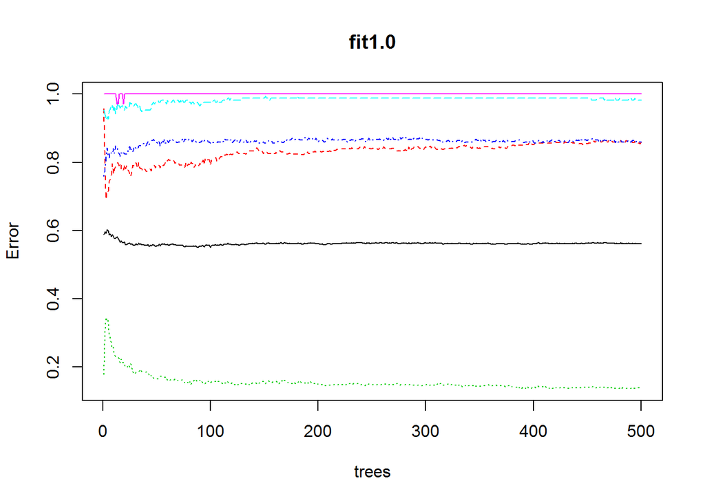

```r
plot(fit1.0)
```

```
## mtry = 1  OOB error = 56.98%
## Searching left ...
## Searching right ...
## mtry = 2     OOB error = 56.07%
## 0.01584786 0.001
## mtry = 4     OOB error = 55.35%
## 0.01288245 0.001
## mtry = 8     OOB error = 57.43%
## -0.03752039 0.001
```

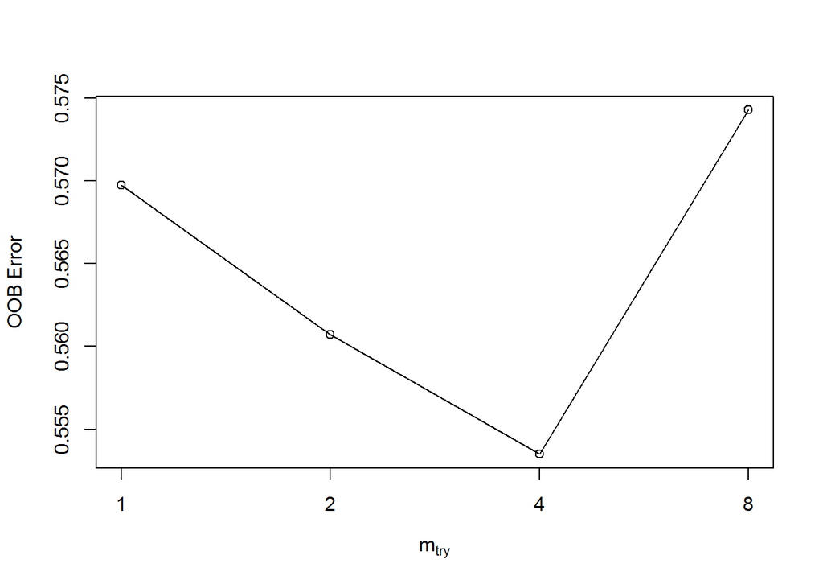

```r
#RF1: OOB error = 56.25%, tune model
fittune1.0 <- tuneRF(train[,-(1:6)], train$grades2, ntreeTry = 500, mtryStart = 1, stepFactor = 2,
                     improve = 0.001, trace = TRUE, plot = TRUE)
```

```r
fittune1.0
```

```
##       mtry  OOBError
## 1.OOB    1 0.5697517
## 2.OOB    2 0.5607223
## 4.OOB    4 0.5534989
## 8.OOB    8 0.5742664
```

```r
#RF1: Four variables per split minimizes OOB error; tuning model
fit1.1 <- randomForest(grades2 ~ ingang + schoolaltercation + outsidealtercation
                       + schoolweapon + outsideweapon + hurtingself + ciguse + tobacco
                       + ecstasy + oxy + otherdrug + sexual + pregnancy + age2 + white
                       + black + asian + hispanic + otherrace + female + alcohol + marijuana
                       + heroin + meth, data = train, mtry=4)
fit1.1
```

```
##
## Call:
##  randomForest(formula = grades2 ~ ingang + schoolaltercation +      outsidealtercation + schoolweapon + outsideweapon + hurtingself +      ciguse + tobacco + ecstasy + oxy + otherdrug + sexual + pregnancy +      age2 + white + black + asian + hispanic + otherrace + female +      alcohol + marijua…
##                Type of random forest: classification
##                      Number of trees: 500
## No. of variables tried at each split: 4
##
##         OOB estimate of  error rate: 55.62%
## Confusion matrix:
##                   Mostly A's Mostly B's Mostly C's Mostly D's
## Mostly A's                89        420         19          0
## Mostly B's                69        818         65          1
## Mostly C's                21        430         73          3
## Mostly D's                 1        134         34          3
## Mostly E's or F's          0         31          4          0
##                   Mostly E's or F's class.error
## Mostly A's                        0   0.8314394
## Mostly B's                        0   0.1416579
## Mostly C's                        0   0.8614801
## Mostly D's                        0   0.9825581
## Mostly E's or F's                 0   1.0000000
```

```r
#RF1: Unfortunately, the OOB error is still fairly high, but we will test the model anyway
pred.rf.train <- predict(fit1.1, train, type='prob')
pred.rf.test <- predict(fit1.1, test, type='prob')
input.rf <- rbind(data.frame(model = "train", d = train$grades2, m = pred.rf.train),
                  data.frame(model = "test", d = test$grades2, m = pred.rf.test))

#RF1: Plot ROC for grade = Mostly A's; resulting plot switches axis of Mostly A's and not A's; test AUC = 0.6766
a <- input.rf
a$d <- as.factor(a$d)
revalue(a$d, c("Mostly B's" = "Not A's")) -> a$d
revalue(a$d, c("Mostly C's" = "Not A's")) -> a$d
revalue(a$d, c("Mostly D's" = "Not A's")) -> a$d
revalue(a$d, c("Mostly E's or F's" = "Not A's")) -> a$d
roc.rf <- ggplot(a, aes(d = d, model = model, m = m.Mostly.A.s, colour = model)) +
  geom_roc(show.legend = TRUE) + style_roc() + ggtitle("Train")
calc_auc(roc.rf)
```

```
##   PANEL group       AUC
## 1     1     1 0.2112472
## 2     1     2 0.3234421
```

```r
#RF1: Plot ROC for grade = Mostly B's; resulting plot switches axis of Mostly B's and not B's; test AUC = 0.301
b <- input.rf
b$d <- as.factor(b$d)
revalue(b$d, c("Mostly A's" = "Not B's")) -> b$d
revalue(b$d, c("Mostly C's" = "Not B's")) -> b$d
revalue(b$d, c("Mostly D's" = "Not B's")) -> b$d
revalue(b$d, c("Mostly E's or F's" = "Not B's")) -> b$d
roc.rf2 <- ggplot(b, aes(d = d, model = model, m = m.Mostly.B.s, colour = model)) +
  geom_roc(show.legend = TRUE) + style_roc() + ggtitle("Train")
calc_auc(roc.rf2)
```

```
##   PANEL group       AUC
## 1     1     1 0.3009447
## 2     1     2 0.4517517
```

```r
#RF1: Plot ROC for grade = Mostly C's; resulting plot switches axis of Mostly C's and not C's; test AUC = 0.236
c <- input.rf
c$d <- as.factor(c$d)
revalue(c$d, c("Mostly A's" = "Not C's")) -> c$d
revalue(c$d, c("Mostly B's" = "Not C's")) -> c$d
revalue(c$d, c("Mostly D's" = "Not C's")) -> c$d
revalue(c$d, c("Mostly E's or F's" = "Not C's")) -> c$d
roc.rf3 <- ggplot(c, aes(d = d, model = model, m = m.Mostly.C.s, colour = model)) +
  geom_roc(show.legend = TRUE) + style_roc() + ggtitle("Train")
calc_auc(roc.rf3)
```

```
##   PANEL group      AUC
## 1     1     1 0.235664
## 2     1     2 0.406936
```

```r
#RF1: Plot ROC for grade = Mostly D's; resulting plot switches axis of Mostly D's and not D's; test AUC = 0.188
d <- input.rf
d$d <- as.factor(d$d)
revalue(d$d, c("Mostly A's" = "Not D's")) -> d$d
revalue(d$d, c("Mostly B's" = "Not D's")) -> d$d
revalue(d$d, c("Mostly C's" = "Not D's")) -> d$d
revalue(d$d, c("Mostly E's or F's" = "Not D's")) -> d$d
roc.rf4 <- ggplot(d, aes(d = d, model = model, m = m.Mostly.D.s, colour = model)) +
  geom_roc(show.legend = TRUE) + style_roc() + ggtitle("Train")
calc_auc(roc.rf4)
```

```
##   PANEL group       AUC
## 1     1     1 0.1875847
## 2     1     2 0.2495748
```

```r
#RF1: Plot ROC for grade = Mostly E's or F's; resulting plot switches axis; test AUC = 0.142
e <- input.rf
e$d <- as.factor(e$d)
revalue(e$d, c("Mostly A's" = "Not E's")) -> e$d
revalue(e$d, c("Mostly B's" = "Not E's")) -> e$d
revalue(e$d, c("Mostly C's" = "Not E's")) -> e$d
revalue(e$d, c("Mostly D's" = "Not E's")) -> e$d
roc.rf5 <- ggplot(e, aes(d = d, model = model, m = m.Mostly.E.s.or.F.s, colour = model)) +
  geom_roc(show.legend = TRUE) + style_roc() + ggtitle("Train")
calc_auc(roc.rf5)
```

```
##   PANEL group       AUC
## 1     1     1 0.1423657
## 2     1     2 0.2904328
```

```r
#RF1: Predict activity for validate sample; only 43.5% were correctly classified using RF1
validate$gradepred <- predict(fit1.1, validate, type='class')
validate$correct[validate$grades2 == validate$gradepred] <- 1
validate$correct[validate$grades2 != validate$gradepred] <- 0
mean(validate$correct)
```

```
## [1] 0.4352442
```

```r
#RF1: Variable importance; age has the most importance, followed by marijuana use, gender, sexual activity and alcohol use
fit1.1$importance
```

```
##                    MeanDecreaseGini
## ingang                     8.169895
## schoolaltercation         16.017567
## outsidealtercation        19.747189
## schoolweapon               8.482969
## outsideweapon             16.629662
## hurtingself               16.826139
## ciguse                    17.581044
## tobacco                    6.541737
## ecstasy                    5.052518
## oxy                        3.555228
## otherdrug                  7.653669
## sexual                    21.507228
## pregnancy                 11.928904
## age2                      49.969373
## white                     17.040204
## black                     11.713651
## asian                     17.080971
## hispanic                  14.786111
## otherrace                 12.591051
## female                    22.675758
## alcohol                   20.400265
## marijuana                 22.882414
## heroin                     0.640794
## meth                       1.642547
```

```r
#RF1: Using only complete observations, RF provides low predictability power, possibly because sample is too small

#Second iteration (RF2): impute missing data on independent variables
df3 <- df[c(1:3, 12, 194:219)]

#RF2: Include only observations without missing values for grade, race, gender and age
df3 <- df3[!is.na(df3[,6]),]
df3 <- df3[!is.na(df3[,20]),]
df3 <- df3[!is.na(df3[,21]),]
df3 <- df3[!is.na(df3[,26]),]

#RF2: View summary of NA values
summary(df3)
```

```
##   survey          year            id                    skl_gra
##      :1285   Min.   :2002   Min.   :   2   Mostly B's       :2857
##  SH04:1269   1st Qu.:2004   1st Qu.: 329   Mostly C's       :1979
##  SH06: 907   Median :2008   Median : 670   Mostly A's       :1395
##  SH08: 965   Mean   :2007   Mean   :1194   Mostly D's       : 617
##  SH10: 884   3rd Qu.:2010   3rd Qu.:1330   Mostly E's or F's: 170
##  SH12: 840   Max.   :2014   Max.   :9999                    :   0
##  SH14: 868                  NA's   :1298   (Other)          :   0
##      grades        grades2              ingang       schoolaltercation
##  Min.   :1.000   Length:7018        Min.   :0.0000   Min.   :0.0000
##  1st Qu.:3.000   Class :character   1st Qu.:0.0000   1st Qu.:0.0000
##  Median :4.000   Mode  :character   Median :0.0000   Median :0.0000
##  Mean   :3.668                      Mean   :0.0406   Mean   :0.1051
##  3rd Qu.:4.000                      3rd Qu.:0.0000   3rd Qu.:0.0000
##  Max.   :5.000                      Max.   :1.0000   Max.   :1.0000
##                                     NA's   :1458     NA's   :1309
##  outsidealtercation  schoolweapon    outsideweapon     hurtingself
##  Min.   :0.0000     Min.   :0.0000   Min.   :0.0000   Min.   :0.000
##  1st Qu.:0.0000     1st Qu.:0.0000   1st Qu.:0.0000   1st Qu.:0.000
##  Median :0.0000     Median :0.0000   Median :0.0000   Median :0.000
##  Mean   :0.1928     Mean   :0.0463   Mean   :0.1045   Mean   :0.131
##  3rd Qu.:0.0000     3rd Qu.:0.0000   3rd Qu.:0.0000   3rd Qu.:0.000
##  Max.   :1.0000     Max.   :1.0000   Max.   :1.0000   Max.   :1.000
##  NA's   :1317       NA's   :1310     NA's   :1316     NA's   :3487
##      ciguse          tobacco           ecstasy            oxy
##  Min.   :0.0000   Min.   :0.00000   Min.   :0.0000   Min.   :0.0000
##  1st Qu.:0.0000   1st Qu.:0.00000   1st Qu.:0.0000   1st Qu.:0.0000
##  Median :0.0000   Median :0.00000   Median :0.0000   Median :0.0000
##  Mean   :0.1409   Mean   :0.02144   Mean   :0.0221   Mean   :0.0155
##  3rd Qu.:0.0000   3rd Qu.:0.00000   3rd Qu.:0.0000   3rd Qu.:0.0000
##  Max.   :1.0000   Max.   :1.00000   Max.   :1.0000   Max.   :1.0000
##  NA's   :78       NA's   :114       NA's   :1324     NA's   :1340
##    otherdrug          sexual         pregnancy           age2
##  Min.   :0.0000   Min.   :0.0000   Min.   :0.0000   Min.   :13.00
##  1st Qu.:0.0000   1st Qu.:0.0000   1st Qu.:0.0000   1st Qu.:15.00
##  Median :0.0000   Median :0.0000   Median :0.0000   Median :16.00
##  Mean   :0.0213   Mean   :0.4698   Mean   :0.0508   Mean   :16.26
##  3rd Qu.:0.0000   3rd Qu.:1.0000   3rd Qu.:0.0000   3rd Qu.:17.00
##  Max.   :1.0000   Max.   :1.0000   Max.   :1.0000   Max.   :18.00
##  NA's   :1335     NA's   :258      NA's   :347
```

[output cut: 9 more lines]

```
##  Min.   :0.0000   Min.   :0.0000   Min.   :0.0000   Min.   :0.0000
##  1st Qu.:0.0000   1st Qu.:0.0000   1st Qu.:0.0000   1st Qu.:0.0000
##  Median :0.0000   Median :1.0000   Median :0.0000   Median :0.0000
##  Mean   :0.1151   Mean   :0.5222   Mean   :0.3585   Mean   :0.2088
##  3rd Qu.:0.0000   3rd Qu.:1.0000   3rd Qu.:1.0000   3rd Qu.:0.0000
##  Max.   :1.0000   Max.   :1.0000   Max.   :1.0000   Max.   :1.0000
##                                    NA's   :75       NA's   :98
##      heroin            meth
##  Min.   :0.0000   Min.   :0.0000
##  1st Qu.:0.0000   1st Qu.:0.0000
##  Median :0.0000   Median :0.0000
##  Mean   :0.0049   Mean   :0.0084
##  3rd Qu.:0.0000   3rd Qu.:0.0000
##  Max.   :1.0000   Max.   :1.0000
##  NA's   :1315     NA's   :1319
```

```r
#RF2: Remove additional columns, impute values; some warnings appear (NAs introduced by coercion)
df4 <- df3[-c(1:5)]
#It should be noted that this following code may take 5 to 10 minutes
df5 <- kNN(df4, variable = c(2:14, 22:25), k=5)
summary(df5)
```

```
##    grades2              ingang       schoolaltercation outsidealtercation
##  Length:7018        Min.   :0.0000   Min.   :0.0000    Min.   :0.0000
##  Class :character   1st Qu.:0.0000   1st Qu.:0.0000    1st Qu.:0.0000
##  Mode  :character   Median :0.0000   Median :0.0000    Median :0.0000
##                     Mean   :0.1512   Mean   :0.2254    Mean   :0.2915
##                     3rd Qu.:0.0000   3rd Qu.:0.0000    3rd Qu.:1.0000
##                     Max.   :1.0000   Max.   :1.0000    Max.   :1.0000
##   schoolweapon    outsideweapon     hurtingself        ciguse
##  Min.   :0.0000   Min.   :0.0000   Min.   :0.000   Min.   :0.0000
##  1st Qu.:0.0000   1st Qu.:0.0000   1st Qu.:0.000   1st Qu.:0.0000
##  Median :0.0000   Median :0.0000   Median :0.000   Median :0.0000
##  Mean   :0.1603   Mean   :0.2082   Mean   :0.443   Mean   :0.1425
##  3rd Qu.:0.0000   3rd Qu.:0.0000   3rd Qu.:1.000   3rd Qu.:0.0000
##  Max.   :1.0000   Max.   :1.0000   Max.   :1.000   Max.   :1.0000
##     tobacco           ecstasy            oxy            otherdrug
##  Min.   :0.00000   Min.   :0.0000   Min.   :0.00000   Min.   :0.0000
##  1st Qu.:0.00000   1st Qu.:0.0000   1st Qu.:0.00000   1st Qu.:0.0000
##  Median :0.00000   Median :0.0000   Median :0.00000   Median :0.0000
##  Mean   :0.02223   Mean   :0.1254   Mean   :0.07125   Mean   :0.1146
##  3rd Qu.:0.00000   3rd Qu.:0.0000   3rd Qu.:0.00000   3rd Qu.:0.0000
##  Max.   :1.00000   Max.   :1.0000   Max.   :1.00000   Max.   :1.0000
##      sexual         pregnancy           age2           white
##  Min.   :0.0000   Min.   :0.0000   Min.   :13.00   Min.   :0.0000
##  1st Qu.:0.0000   1st Qu.:0.0000   1st Qu.:15.00   1st Qu.:0.0000
##  Median :0.0000   Median :0.0000   Median :16.00   Median :0.0000
##  Mean   :0.4887   Mean   :0.0721   Mean   :16.26   Mean   :0.4139
##  3rd Qu.:1.0000   3rd Qu.:0.0000   3rd Qu.:17.00   3rd Qu.:1.0000
##  Max.   :1.0000   Max.   :1.0000   Max.   :18.00   Max.   :1.0000
##      black            asian            hispanic        otherrace
##  Min.   :0.0000   Min.   :0.00000   Min.   :0.0000   Min.   :0.0000
##  1st Qu.:0.0000   1st Qu.:0.00000   1st Qu.:0.0000   1st Qu.:0.0000
##  Median :0.0000   Median :0.00000   Median :0.0000   Median :0.0000
##  Mean   :0.1463   Mean   :0.08906   Mean   :0.2355   Mean   :0.1151
##  3rd Qu.:0.0000   3rd Qu.:0.00000   3rd Qu.:0.0000   3rd Qu.:0.0000
##  Max.   :1.0000   Max.   :1.00000   Max.   :1.0000   Max.   :1.0000
##      female          alcohol         marijuana          heroin
##  Min.   :0.0000   Min.   :0.0000   Min.   :0.0000   Min.   :0.00000
##  1st Qu.:0.0000   1st Qu.:0.0000   1st Qu.:0.0000   1st Qu.:0.00000
##  Median :1.0000   Median :0.0000   Median :0.0000   Median :0.00000
##  Mean   :0.5222   Mean   :0.3641   Mean   :0.2135   Mean   :0.06996
```

[output cut: 22 more lines]

```
##
##    13_imp          14_imp          22_imp          23_imp
##  Mode :logical   Mode :logical   Mode :logical   Mode :logical
##  FALSE:6760      FALSE:6671      FALSE:6943      FALSE:6920
##  TRUE :258       TRUE :347       TRUE :75        TRUE :98
##  NA's :0         NA's :0         NA's :0         NA's :0
##
##
##    24_imp          25_imp
##  Mode :logical   Mode :logical
##  FALSE:5703      FALSE:5699
##  TRUE :1315      TRUE :1319
##  NA's :0         NA's :0
##
##
```

```r
#RF2: Create new data frame of only variables
df6 <- df5[c(1:25)]

#RF2: 70-15-15 partition
set.seed(100)
rand <- runif(nrow(df6))
train2 <- df6[rand > 0.3,]
validate2 <- df6[rand > 0.15 & rand <= 0.3,]
test2 <- df6[rand <= 0.15,]

#RF2: Include all variables
train2$grades2 <- factor(train2$grades2)
fit2.0 <- randomForest(grades2 ~ ingang + schoolaltercation + outsidealtercation
                       + schoolweapon + outsideweapon + hurtingself + ciguse + tobacco
                       + ecstasy + oxy + otherdrug + sexual + pregnancy + age2 + white
                       + black + asian + hispanic + otherrace + female + alcohol + marijuana
                       + heroin + meth, data = train2)

#RF2: Diagnostics
fit2.0
```

```
##
## Call:
##  randomForest(formula = grades2 ~ ingang + schoolaltercation +      outsidealtercation + schoolweapon + outsideweapon + hurtingself +      ciguse + tobacco + ecstasy + oxy + otherdrug + sexual + pregnancy +      age2 + white + black + asian + hispanic + otherrace + female +      alcohol + marijua…
##                Type of random forest: classification
##                      Number of trees: 500
## No. of variables tried at each split: 4
##
##         OOB estimate of  error rate: 56.7%
## Confusion matrix:
##                   Mostly A's Mostly B's Mostly C's Mostly D's
## Mostly A's               129        736         94          6
## Mostly B's                88       1580        337          8
## Mostly C's                25        909        407         22
## Mostly D's                 6        245        178          8
## Mostly E's or F's          1         56         52          6
##                   Mostly E's or F's class.error
## Mostly A's                        0   0.8663212
## Mostly B's                        5   0.2170466
## Mostly C's                        4   0.7022677
## Mostly D's                        3   0.9818182
## Mostly E's or F's                 0   1.0000000
```

```r
print(importance(fit2.0, type = 2))
```

```
##                    MeanDecreaseGini
## ingang                     24.48160
## schoolaltercation          34.23191
## outsidealtercation         37.09968
## schoolweapon               22.51555
## outsideweapon              31.40988
## hurtingself                42.02763
## ciguse                     43.71706
## tobacco                    17.59558
## ecstasy                    18.98888
## oxy                        17.80505
## otherdrug                  17.90843
## sexual                     50.04320
## pregnancy                  27.14882
## age2                      115.85805
## white                      35.26027
## black                      28.42008
## asian                      36.27921
## hispanic                   28.48058
## otherrace                  24.72503
## female                     50.48644
## alcohol                    42.54319
## marijuana                  41.75054
## heroin                     10.43022
## meth                       13.93494
```

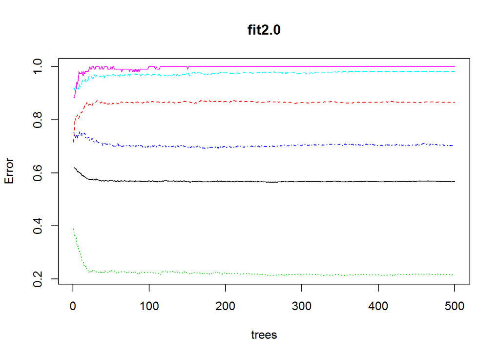

```r
plot(fit2.0)
```